# Generate data for multispecies modeling, including diet!

Sarah Gaichas

11 September, 2020

## Which species?

Let’s use the wrapper functions to get initial multispecies assessment model inputs.

We use config files for the NOBA model, and define multispecies surveys and fisheries. We will also test diet functions which are needed as multispecies and ecosystem model inputs.

Our initial species selection includes 11 single species groups from the NOBA model:

```r
fgs <- load_fgs(here("atlantisoutput", "NOBA_March_2020"), "nordic_groups_v04.csv")

lname <- data.frame(Latin = c("*Hippoglossoides platessoides*",
                              "*Reinhardtius hippoglossoides*",
                              "*Scomber scombrus*",
                              "*Melongrammus aeglefinus*",
                              "*Pollachius virens*",
                              "*Sebastes mentella*",
                              "*Micromesistius poutassou*",
                              "*Clupea harengus*",
                              "*Gadus morhua*",
                              "*Boreogadus saida*",
                              "*Mallotus villosus*"),
                    Code = c("LRD", "GRH", "MAC", "HAD", "SAI", "RED",
                             "BWH", "SSH", "NCO", "PCO", "CAP")
)

sppsubset <- merge(fgs, lname, all.y = TRUE)
spptable <- sppsubset %>%
  arrange(Index) %>%
  select(Name, Long.Name, Latin)

knitr::kable(spptable, col.names = c("Model name", "Full name", "Latin name"))
```

| Model name | Full name | Latin name |
| --- | --- | --- |
| Long_rough_dab | Long rough dab | *Hippoglossoides platessoides* |
| Green_halibut | Greenland halibut | *Reinhardtius hippoglossoides* |
| Mackerel | Mackerel | *Scomber scombrus* |
| Haddock | Haddock | *Melongrammus aeglefinus* |
| Saithe | Saithe | *Pollachius virens* |
| Redfish | Redfish | *Sebastes mentella* |
| Blue_whiting | Blue whiting | *Micromesistius poutassou* |
| Norwegian_ssh | Norwegian spring spawning herring | *Clupea harengus* |
| North_atl_cod | Northeast Atlantic cod | *Gadus morhua* |
| Polar_cod | Polar cod | *Boreogadus saida* |
| Capelin | Capelin | *Mallotus villosus* |

These represent a range of life histories which are similar to those on the Northeast US shelf (some are the same species), so they form a reasonable set of species for multispecies model testing.

### Diet interactions

How much do these species interact with each other? Now we test the diet composition functions in `atlantisom`.

Diet composition is loaded with `load_diet_comp()`:

```r
diettest <- load_diet_comp(here("atlantisoutput", "NOBA_march_2020"),
                           "nordic_runresults_01DietCheck.txt", fgs = fgs)

ms_diet <- diettest %>%
  filter(species %in% sppsubset$Name) %>%
  filter(atoutput>0)
```

### Plotting diets

```r
plist = lapply(split(ms_diet, ms_diet$species), function(d) {
  ggplot(d, aes(time.days/365, atoutput, fill=prey)) +
    geom_bar(stat = "identity") +
    facet_wrap(species~agecl) +
    xlab("year") +
    ylab("diet proportion") +
    theme_tufte() +
    theme(legend.position="bottom")
})
```

#### Capelin

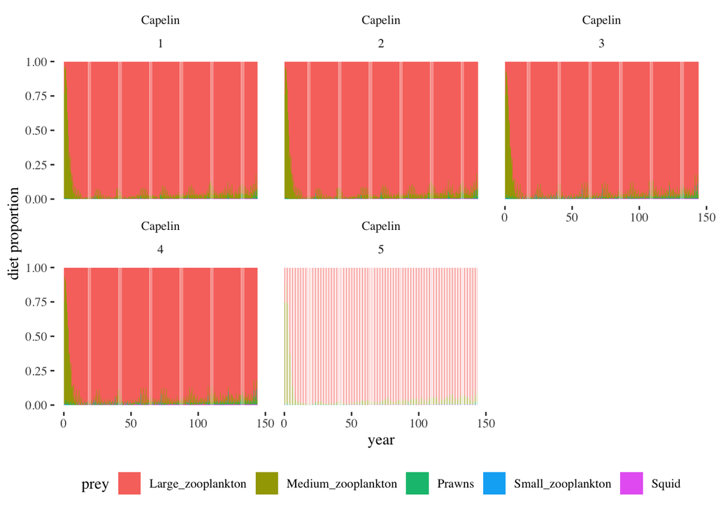

```r
plist$Capelin
```

#### Blue whiting

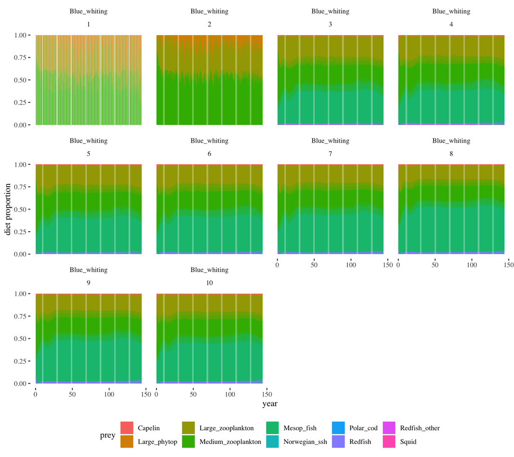

```r
plist$Blue_whiting
```

#### Saithe

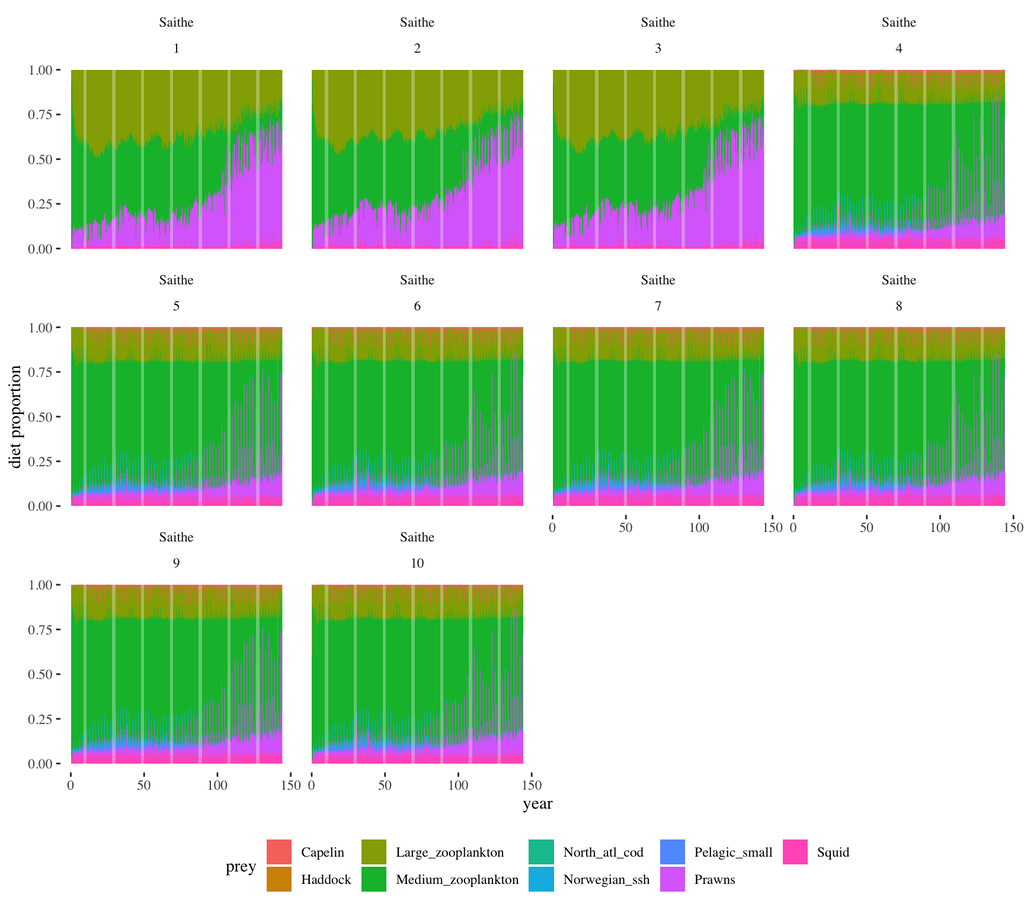

```r
plist$Saithe
```

#### Cod

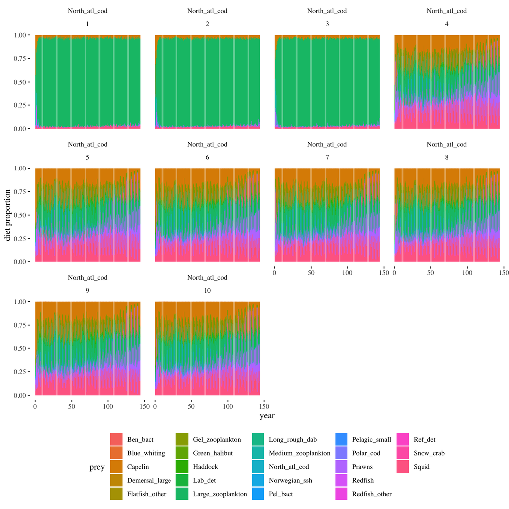

```r
plist$North_atl_cod
```

#### Haddock

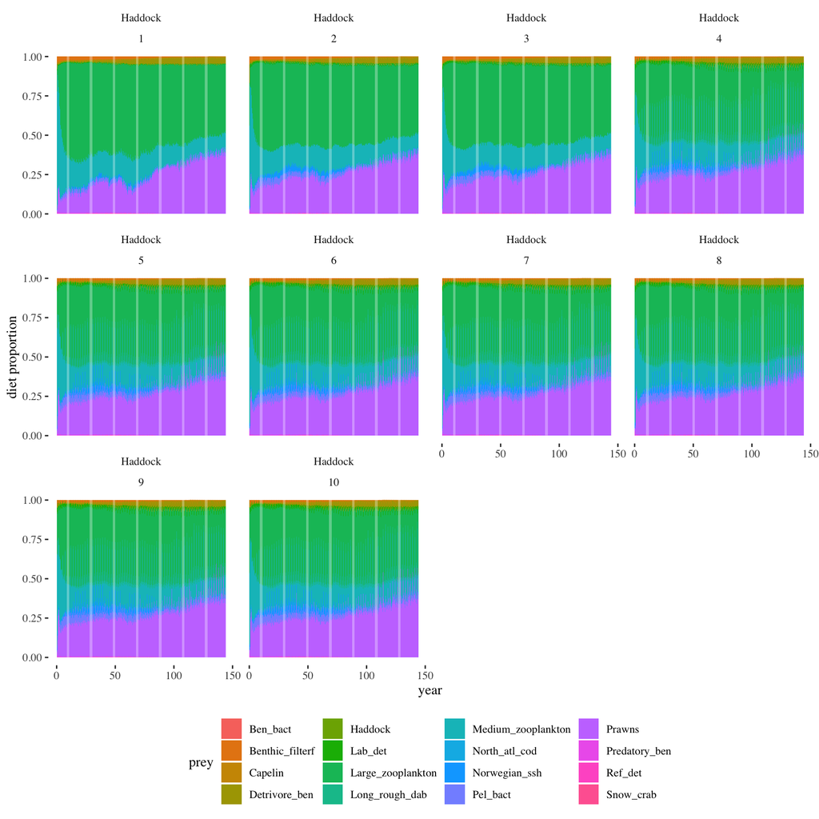

```r
plist$Haddock
```

#### Greenland halibut

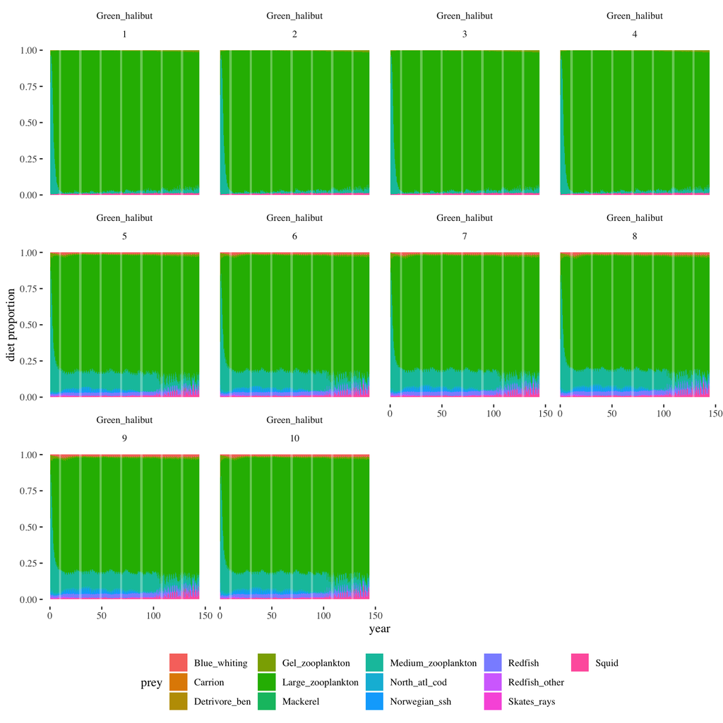

```r
plist$Green_halibut
```

#### Herring

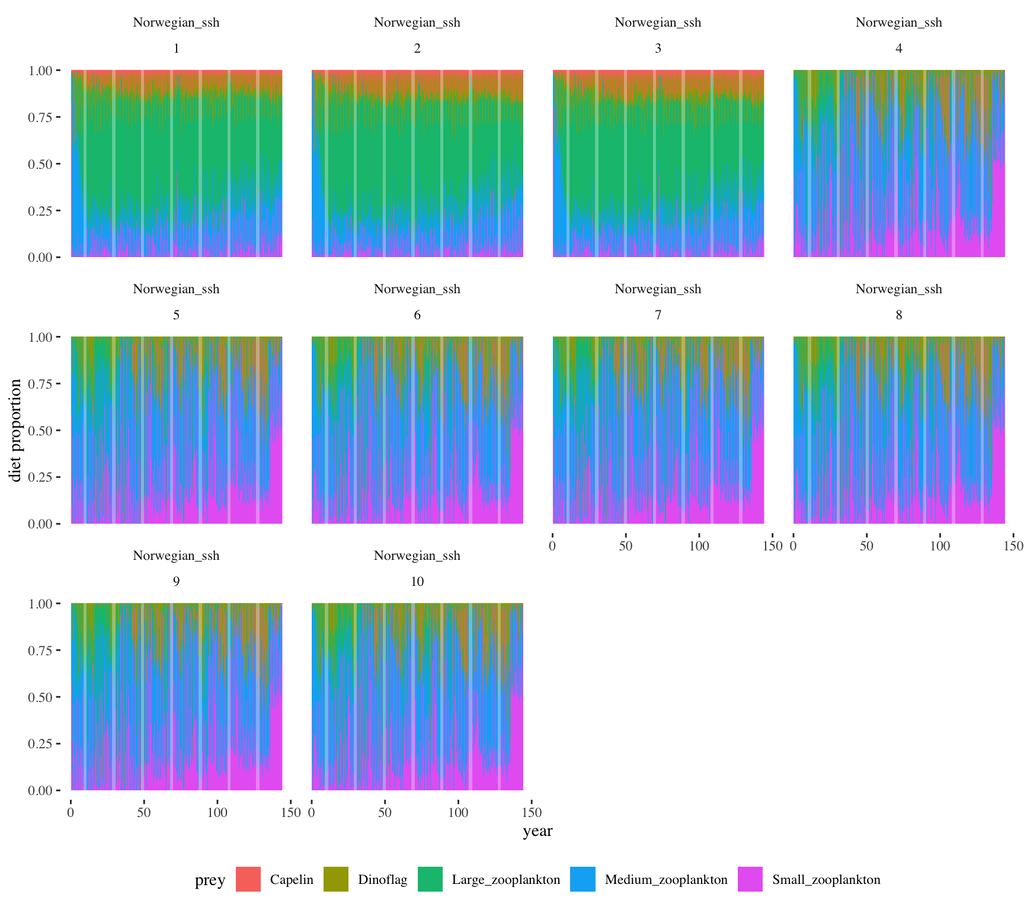

```r
plist$Norwegian_ssh
```

#### Redfish

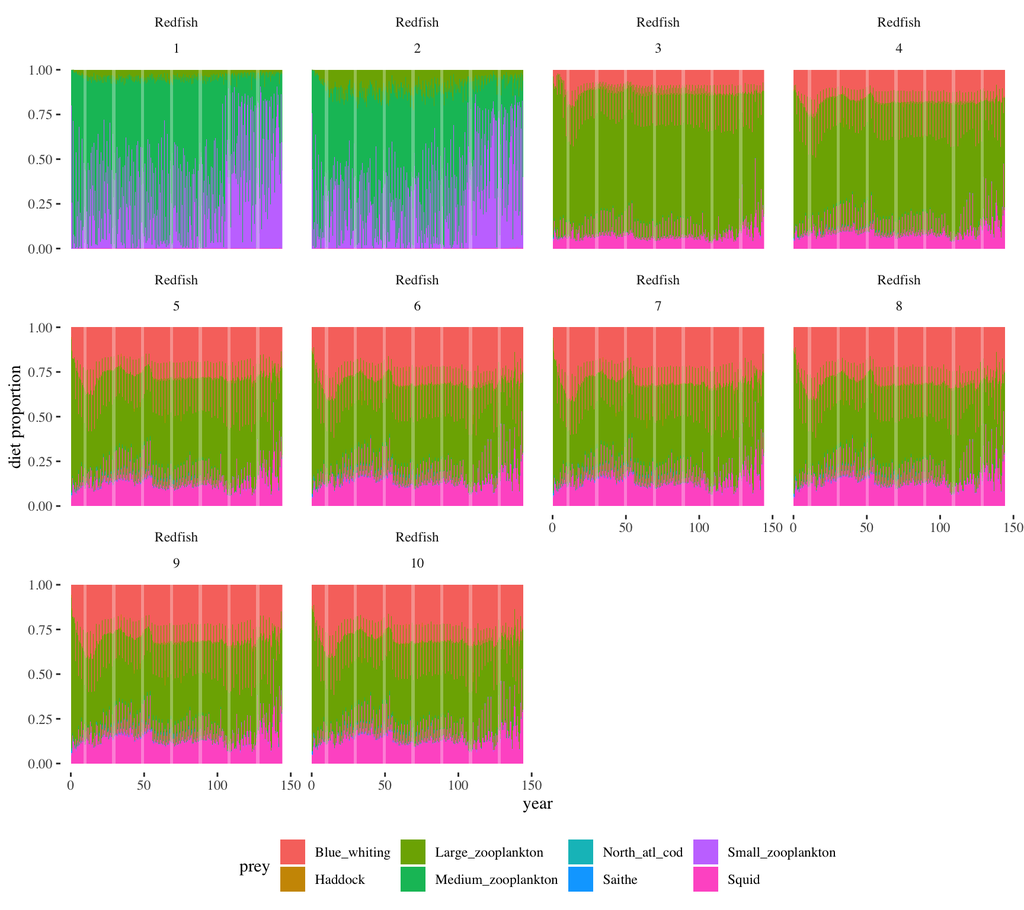

```r
plist$Redfish
```

#### Mackerel

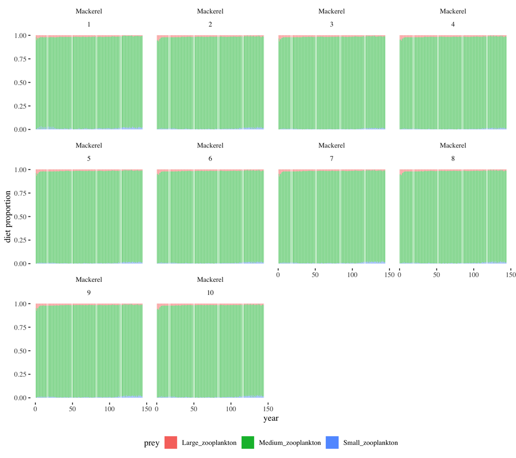

```r
plist$Mackerel
```

#### Long rough dab

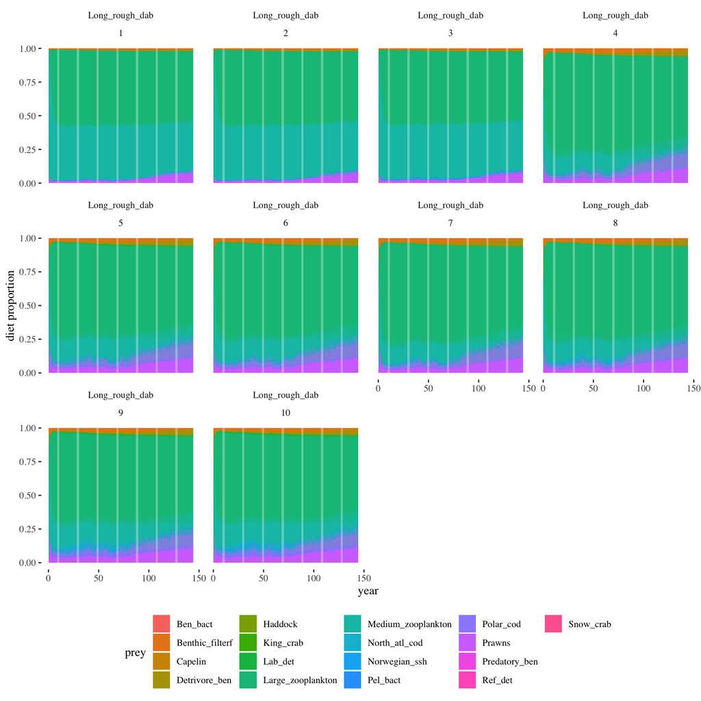

```r
plist$Long_rough_dab
```

#### Polar cod

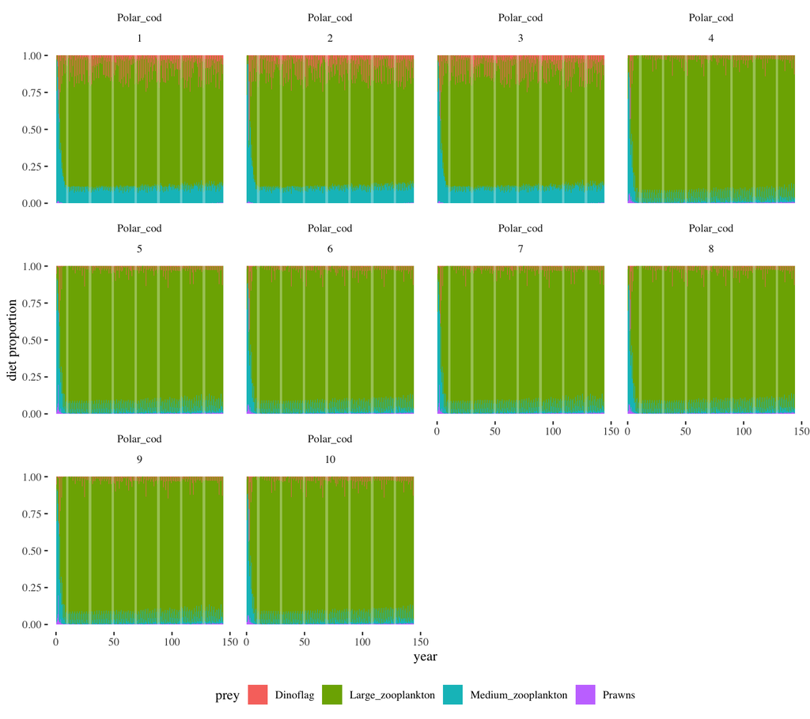

```r
plist$Polar_cod
```

### Interactions among these species

Do our selected species eat each other? What proportion of each species diet comes from species in our selected group?

This table shows the proportion of diet for each species and age class where only our selected species are considered as prey. The statistics are across all time steps in this model run, and *do not* include timesteps where the diet composition was 0.

```r
prop <- ms_diet %>%
  filter(prey %in% unique(species)) %>%
  select(species, agecl, time.days, prey, atoutput) %>%
  group_by(species, agecl, time.days) %>%
  summarise(mspreyprop = sum(atoutput)) #sum over prey each timestep

range <- prop %>%
  group_by(species, agecl) %>%
  summarise(minprop = min(mspreyprop),
         medprop = median(mspreyprop),
         meanprop = mean(mspreyprop),
         maxprop = max(mspreyprop))

#knitr::kable(range)
library(DT)
datatable(range, rownames = FALSE, options = list(pageLength = 25))
```

| species | agecl | minprop | medprop | meanprop | maxprop |
| --- | --- | --- | --- | --- | --- |
| Blue_whiting | 2 | 2.467218e-08 | 7.855102e-07 | 3.14391777406852e-06 | 0.0001437388939 |
| Blue_whiting | 3 | 0.00159302369 | 0.02883976895 | 0.0261364201960764 | 0.1192049362 |
| Blue_whiting | 4 | 0.0018610868 | 0.031025202554 | 0.0288439832646667 | 0.1157009031 |
| Blue_whiting | 5 | 0.0018421235 | 0.0316655823 | 0.0300969706078306 | 0.1039136 |
| Blue_whiting | 6 | 0.0018140903 | 0.032125870545 | 0.0310558983711167 | 0.1085347251 |
| Blue_whiting | 7 | 0.0017865518 | 0.03247634575 | 0.0317094378978514 | 0.1047836581 |
| Blue_whiting | 8 | 0.0016088841 | 0.03250774655 | 0.0316461583105 | 0.0900518996 |
| Blue_whiting | 9 | 0.0017037464 | 0.03263573165 | 0.0319008150217403 | 0.0970094933 |
| Blue_whiting | 10 | 0.0017657733 | 0.03275168957 | 0.0321785684345667 | 0.103995156 |
| Green_halibut | 5 | 0.024081279 | 0.0496414904 | 0.0503601740784722 | 0.0784844312 |

[output cut: 53 more lines]

Mature age classes of cod and redfish average over a third of their diet compositions from other species in the selected group, suggesting fairly strong predation interactions.

Many of the selected species share zooplankton prey, so there may be species interactions via prey as well.

### Total consumption time series

The true data can be generated without updated config files (once I fix missing diets in wrappers!).

UPDATE: added an option to bring in biomass_eaten in the om_species wrapper. However, the way this is calculated is probably inappropriate for what we want. biomass_eaten is the output of box specific total tons consumed by predators from PROD.nc split by global diet comp from DietCheck.txt. This means predators will have the same diet comp in all boxes, whether prey were there or not.

To do diet sampling using our survey design, we need to retain actual box-specific diet. This is found in the DetailedDietCheck.txt file, which outputs tons consumed since last timestep for each predator by box, layer, and prey. Because there is no conversion needed for tons, we can just read this in, get rid of all the zero diet comp values to make it a (possibly) manageable size, and apply the survey from there. A new function `load_detailed_diet_comp.R` is developed below.

Bottom line is don’t use biomass_eaten; maybe we should take it out of `run_truth()` output.

```r
NOBAom <- om_init(here("config/NOBA2config.R")) #run and saved June 19,
# run again 3 August to update biomass_eaten

#NOBAom_ms <- om_species(sppsubset$Name, NOBAom) #run and saved June 19
# run again 3 August to test new wrapper that should save biomass_eaten
NOBAom_ms <- om_species(sppsubset$Name, NOBAom, diet=TRUE)

source(here("config", "NOBA2config.R"))

# diet data are not in here, need to revise wrapper
#NOBAom_ms <- readRDS(file.path(d.name, paste0(scenario.name, "omlist_ss.rds")))

# get from full truth run--big file
#truth <- get(load(file.path(d.name,
#                                paste0(scenario.name, "run_truth.RData"))))

# questions: does biomass_eaten have some diet comp info as dietcheck.txt?
# load dietcheck with om_init using a switch in config file?
# add or pass along switch to keep biomass_eaten truth output in species file
# is biomass_eaten correct?
#   revised load_diet_comp to *not include* NAs that merge poorly
# polygon specific total mg N consumed per unit volume times volume of polygon
# then split to prey using global diet fraction (and converted to t)

#bioeaten_ss <- truth$biomass_eaten %>%
#  filter(species %in% sppsubset$Name)

# compare ms_diet$atoutput to bioeaten_ss$dietfrac
# should match for species, agecl, time.days, prey

cod5.365 <- NOBAom_ms$truebioeaten_ss %>%
  filter(species=="North_atl_cod",
         agecl==5,
         time.days==365,
         polygon==4)

cod5.365.check <- ms_diet %>%
  filter(species=="North_atl_cod",
         agecl==5,
         time.days==365)

#it does, but I think we need this by box
#it makes no sense to apply global diet comp to boxes, not all prey
#may be in the box
#DetailedDietCheck.txt is the file to read for using survey sampling.

#this file is huge, try data.table::fread
detaileddiettest <- data.table::fread(file.path(here("atlantisoutput", "NOBAwithAnnAgeOutput"), "outputnordic_runresults_01DetailedDietCheck.txt"),
                                      data.table=FALSE
                                      #nrows = 200
                                      )

diet <- detaileddiettest

#remove rows that are all 0 prey
#diet <- diet[apply(diet[,-c(1:5)], 1, function(x) !all(x==0)),]

#should do the same thing faster
diet <- diet[as.logical(abs(as.matrix(diet[,-c(1:5)])) %*% rep(1L,ncol(diet[,-c(1:5)]))), ]

#test pieces of new load_detailed_diet function
  if(length(grep("Group",colnames(diet)))>0)
    colnames(diet) <- gsub("Group","Predator",colnames(diet))

  # Change column order
  diet <- diet[, c("Predator", "Cohort", "Time", "Box", "Layer",
    names(diet)[which(!names(diet) %in% c("Predator", "Cohort", "Time", "Box", "Layer"))])]

  # Convert to tidy dataframe to allow joining/merging with other dataframes.
  diet <- tidyr::gather_(data = diet, key_col = "prey", value_col = "dietcomp",
    #gather_cols = names(diet)[(which(names(diet) == "Updated") + 1):NCOL(diet)])
    gather_cols = names(diet)[(which(names(diet) %in% fgs$Code))])

  # Get rid of 0 dietcomp rows to make manageable size
  diet <- filter(diet, dietcomp>0)

  names(diet) <- tolower(names(diet))

  diet$prey <- as.character(diet$prey)
  diet$predator <- as.character(diet$predator)

  # Change species acronyms to actual names.
  species_names <- fgs[, c("Name", "Code")]
  diet$species <- species_names$Name[match(diet$predator, species_names$Code)]
  diet$prey <- species_names$Name[match(diet$prey, species_names$Code)]

  # diet outputs are not all divisible by toutinc, leave in days
  diet$time.days <- diet$time #/ toutinc

  #fix cohort to agecl

  diet <- diet %>%
    dplyr::mutate(agecl = cohort + 1)

  # drop redundant columns and reorder
  diet <- diet[,c("species", "agecl", "time.days", "box", "layer", "prey", "dietcomp")]
```

Try reading in the box-specific diet in weight and see if the proportions match dietcheck.txt outputs:

Oy, have to deal with filesize first. Try stripping out all the 0 lines:

Even running a “bash” chunk here is still running R `system2()`; I don’t think this is worth it. Cant even count the columns without the fans kicking up.

The awk code, for the record, is this, executed in terminal from the directory with the .gz file in it:

```
zcat < nordic_runresults_01DetailedDietCheck.txt.gz | awk 'NR > 1{s=0; for (i=6;i<=NF;i++) s+=$i; if (s!=0)print}' | gzip > DetDiet.gz
```

On linux it would just say zcat filename; macOS needs zcat < filename to work. The awk statement is saying after the header row (NR>1), sum up the values from column 6 to the last column and keep the row if they are >0. The last pipe sends the new file to a zip file.

Links consulted: [awk is the right thing](https://www.tim-dennis.com/data/tech/2016/08/09/using-awk-filter-rows.html)

[awk to delete lines summing to 0](https://unix.stackexchange.com/questions/170588/delete-lines-that-sum-to-zero)

[awk a compressed file leaving it compressed](https://unix.stackexchange.com/questions/498587/how-to-extract-information-using-awk-on-gz-files-without-storing-the-uncompress)

Started command at 5:35 pm. Finished at 6:58. Maybe I can fread the output smaller file?

I can but it stripped off the header. So I need to grab that and cat it back together. cat works on two gzipped files, so check it with first line, make the zip version with second, and concatenate them with third.

```
zcat < nordic_runresults_01DetailedDietCheck.txt.gz | head -n1 > DetDietHead.txt
zcat < nordic_runresults_01DetailedDietCheck.txt.gz | head -n1 | gzip > DetDietHead.gz
cat DetDietHead.gz DetDiet.gz > NOBADetDiet.gz
```

Now we diagnose the load function again and try to optimize with data.table functions.

```r
#keeps failing with vector memory exhausted (limit reached?)
#gets to the step of eliminating 0 rows
#try awk in a system command
# this test works but R overhead isnt worth it, faster run from terminal
#system("zcat < atlantisoutput/NOBA_march_2020/nordic_runresults_01DetailedDietCheck.txt.gz | awk '{print NF}' | uniq")
# see notes above for preprocessing step, here debug new load_detailed_diet function

dir <- here("atlantisoutput","NOBA_march_2020")
file_diet <-  "NOBADetDiet.gz"

  if (is.null(dir)) {
    diet.file <- file_diet
  } else {
    diet.file <- file.path(dir, file_diet)
  }
  diet <- data.table::fread(diet.file)

  # remove all 0 prey rows--done with awk statement first, file is too big for R to do this
  #diet <- diet[as.logical(rowSums(diet[,-c(1:5)] != 0)), ]


  # SKG June 2020: changing to the other way around. more new models now,
  # only one diet function to change, and "Predator" seems clearer for users.
  if(length(grep("Group",colnames(diet)))>0)
    colnames(diet) <- gsub("Group","Predator",colnames(diet))

  # Change column order NOT DATA TABLE SAFE
  #diet <- diet[, c("Predator", "Cohort", "Time", "Box", "Layer",
  #  names(diet)[which(!names(diet) %in% c("Predator", "Cohort", "Time", "Box", "Layer"))])]

  # Change column order
  data.table::setcolorder(diet, c("Predator", "Cohort", "Time", "Box", "Layer"))

  diet <- data.table::melt(diet, id = 1:5,
               variable.name="prey",
               value.name = "dietcomp")

  # # Convert to tidy dataframe to allow joining/merging with other dataframes.
  # diet <- tidyr::gather_(data = diet, key_col = "prey", value_col = "dietcomp",
  #   #gather_cols = names(diet)[(which(names(diet) == "Updated") + 1):NCOL(diet)])
  #   gather_cols = names(diet)[(which(names(diet) %in% fgs$Code))])

  # Get rid of 0 dietcomp rows to make manageable size
  diet <- diet[dietcomp>0]
  #diet <- filter(diet, dietcomp>0)

  names(diet) <- tolower(names(diet))

  diet$prey <- as.character(diet$prey)
  diet$predator <- as.character(diet$predator)

  # Change species acronyms to actual names.
  species_names <- fgs[, c("Name", "Code")]
  diet$species <- species_names$Name[match(diet$predator, species_names$Code)]
  diet$prey <- species_names$Name[match(diet$prey, species_names$Code)]
  #diet <- diet[, -which(colnames(diet) == "predator")]

  # diet outputs are not all divisible by toutinc, leave in days
  diet$time.days <- diet$time #/ toutinc

  #fix cohort to agecl
  # diet <- diet %>%
  #   dplyr::mutate(agecl = cohort + 1)
  diet <- diet[, agecl := cohort + 1]

  # drop redundant columns and reorder NOT DATA TABLE SAFE
  #diet <- diet[,c("species", "agecl", "time.days", "box", "layer", "prey", "dietcomp")]

  #leave layer info for now, this is a load function

  #does the Update column matter? this assumes it doesn't
  #in SETAS_Example, it doesn't make extra comps

  dietcompwt <- data.frame(species = diet$species,
                         agecl = diet$agecl,
                         time.days = diet$time.days,
                         polygon = diet$box,
                         layer = diet$layer,
                         atoutput = diet$dietcomp,
                         prey = diet$prey)
```

Using `data.table` improves speed for the `atantisom::load_detailed_diet_comp()` function. But it turns out you need to import data.table within a package in *both* the DESCRIPTION and NAMESPACE files [instructions!](https://cran.r-project.org/web/packages/data.table/vignettes/datatable-importing.html) and now this beast of a function works.

```r
# still not working but works line by line--fixed
# N.B. data.table wants to be in both imports and namespace within a function!
detdiet <- load_detailed_diet_comp(here("atlantisoutput","NOBA_march_2020"),
                                   "NOBADetDiet.gz",
                                   fgs = fgs)

ms_detaileddiet <- detdiet %>%
  filter(species %in% sppsubset$Name)

saveRDS(ms_detaileddiet, file.path(d.name, paste0(scenario.name, "ms_detaileddiet.rds")))
```

All this was just to see what the regional diet data looks like compared with global diet comps from DietCheck.txt.

```r
# look at a single species/age combo from above

# how many polygons included? how many layers per polygon have data?

# are there differences by layer within a polygon?

# are there differences by polygon? (aggregate layers)
```

## Generating the dataset

Now to get a range of data:

### Config files

`NOBA2config.R` looks like this (adjusted from Alfonso’s original):

```r
d.name <- here("atlantisoutput","NOBA_march_2020")
functional.groups.file <- "nordic_groups_v04.csv"
biomass.pools.file <- "nordic_biol_v23.nc"
biol.prm.file <- "nordic_biol_incl_harv_v_007_3.prm"
box.file <- "Nordic02.bgm"
initial.conditions.file <- "nordic_biol_v23.nc"
run.prm.file <- "nordic_run_v01.xml"
scenario.name <- "nordic_runresults_01"
bioind.file <- "nordic_runresults_01BiomIndx.txt"
catch.file <- "nordic_runresults_01Catch.txt"
annage <- TRUE
fisheries.file <- "NoBAFisheries.csv"
```

`omdimensions.R` standardizes timesteps, etc. (this is part of atlantisom and should not need to be changed by the user):

```r
#survey species inherited from omlist_ss
survspp <- omlist_ss$species_ss
# survey season and other time dimensioning parameters
# generalized timesteps all models
noutsteps <- omlist_ss$runpar$tstop/omlist_ss$runpar$outputstep
timeall <- c(0:noutsteps)
stepperyr <- if(omlist_ss$runpar$outputstepunit=="days") 365/omlist_ss$runpar$toutinc
midptyr <- round(median(seq(0,stepperyr)))

# model areas, subset in surveyconfig
allboxes <- c(0:(omlist_ss$boxpars$nbox - 1))

# fishery output: learned the hard way this can be different from ecosystem outputs
fstepperyr <- if(omlist_ss$runpar$outputstepunit=="days") 365/omlist_ss$runpar$toutfinc

# survey selectivity (agecl based)
# should return all age classes fully sampled (Atlantis output is 10 age groups per spp)
n_age_classes <- omlist_ss$funct.group_ss$NumCohorts
# changed below for multiple species
age_classes <- sapply(n_age_classes, seq)
names(age_classes)<-survspp

n_annages <- n_age_classes * omlist_ss$funct.group_ss$NumAgeClassSize
# changed below for multiple species
annages <- sapply(n_annages, seq)
names(annages)<-survspp
```

`mssurvey_spring.R` and `mssurvey_fall.R` configure the fishery independent surveys:

```r
# Default survey configuration here has a range of efficiencies and selectivities
# To emulate a range of species in a single multispecies survey
# Also now happens in "spring" and "fall"
# Need to define survey season, area, efficiency, selectivity

#Atlantis model timestep corresponding to the true output--now from census_spec.R
timestep <- stepperyr #5

#Which atlantis timestep does the survey run in?--now from census_spec.R
# with 5 output steps per year, 0 is Jan-Feb-midMar, 1 is midMar-Apr-May,
# 2 is June-July-midAug, 3 is midAug-Sept-Oct, 4 is Nov-Dec (ish)

survey_sample_time <- 1 # spring survey

#The last timestep to sample
total_sample <- noutsteps-1 #495

#Vector of indices of survey times to pull
survey_sample_full <- seq(survey_sample_time,
                          total_sample, by=timestep)

survtime <- survey_sample_full

# survey area
# should return all model areas
survboxes <- allboxes

# survey efficiency (q)
# should return a perfectly efficient survey
surveffic <- data.frame(species=survspp,
                     efficiency=rep(1.0,length(survspp)))

# survey selectivity (agecl based)
# this is by age class, need to change to use with ANNAGEBIO output
#survselex <- data.frame(species=rep(survspp, each=n_age_classes),
#                     agecl=rep(c(1:n_age_classes),length(survspp)),
#                     selex=rep(1.0,length(survspp)*n_age_classes))

# for annage output
survselex <- data.frame(species=rep(survspp, n_annages), #
                        agecl=unlist(sapply(n_annages,seq)),
                        selex=rep(1.0,sum(n_annages)))

# effective sample size needed for sample_fish
# this effective N is high but not equal to total for numerous groups
surveffN <- data.frame(species=survspp, effN=rep(1000, length(survspp)))

# survey index cv needed for sample_survey_xxx
# cv = 0.1
surv_cv <- data.frame(species=survspp, cv=rep(0.1,length(survspp)))

# length at age cv for input into calc_age2length function
# function designed to take one cv for all species, need to change to pass it a vector
lenage_cv <- 0.1

# max size bin for length estimation, function defaults to 150 cm if not supplied
maxbin <- 200
```

```r
# Default survey configuration here has a range of efficiencies and selectivities
# To emulate a range of species in a single multispecies survey
# Also now happens in "spring" and "fall"
# Need to define survey season, area, efficiency, selectivity

#Atlantis model timestep corresponding to the true output--now from census_spec.R
timestep <- stepperyr #5

#Which atlantis timestep does the survey run in?--now from census_spec.R
# with 5 output steps per year, 0 is Jan-Feb-midMar, 1 is midMar-Apr-May,
# 2 is June-July-midAug, 3 is midAug-Sept-Oct, 4 is Nov-Dec (ish)

survey_sample_time <- 3 # fall survey

#The last timestep to sample
total_sample <- noutsteps-1 #495

#Vector of indices of survey times to pull
survey_sample_full <- seq(survey_sample_time,
                          total_sample, by=timestep)

survtime <- survey_sample_full

# survey area
# should return all model areas
survboxes <- allboxes

# survey efficiency (q)
# should return a perfectly efficient survey
surveffic <- data.frame(species=survspp,
                     efficiency=rep(1.0,length(survspp)))

# survey selectivity (agecl based)
# this is by age class, need to change to use with ANNAGEBIO output
#survselex <- data.frame(species=rep(survspp, each=n_age_classes),
#                     agecl=rep(c(1:n_age_classes),length(survspp)),
#                     selex=rep(1.0,length(survspp)*n_age_classes))

# for annage output
survselex <- data.frame(species=rep(survspp, n_annages), #
                        agecl=unlist(sapply(n_annages,seq)),
                        selex=rep(1.0,sum(n_annages)))

# effective sample size needed for sample_fish
# this effective N is high but not equal to total for numerous groups
surveffN <- data.frame(species=survspp, effN=rep(1000, length(survspp)))

# survey index cv needed for sample_survey_xxx
# cv = 0.1
surv_cv <- data.frame(species=survspp, cv=rep(0.1,length(survspp)))

# length at age cv for input into calc_age2length function
# function designed to take one cv for all species, need to change to pass it a vector
lenage_cv <- 0.1

# max size bin for length estimation, function defaults to 150 cm if not supplied
maxbin <- 200
```

`msfishery.R` configures the fishery dependent data:

```r
# Default fishery configuration here is a census
# Inherits species from input omlist_ss
fishspp <- omlist_ss$species_ss

#Number of years of data to pull
nyears <- 50

#Atlantis initialization period in years
burnin <- 30

# fishery output: learned the hard way this can be different from ecosystem outputs
fstepperyr <- if(omlist_ss$runpar$outputstepunit=="days") 365/omlist_ss$runpar$toutfinc


# same time dimensioning parameters as in surveycensus.R
#Vector of indices of catch in numbers to pull (by timestep to sum)
fish_sample_full <- c(0:total_sample)  #total_sample defined in sardinesurvey.R
fish_burnin <- burnin*fstepperyr+1
fish_nyears <- nyears*fstepperyr
fish_times <- fish_sample_full[fish_burnin:(fish_burnin+fish_nyears-1)]
fish_timesteps <- seq(fish_times[fstepperyr], max(fish_times), by=fstepperyr) #last timestep
#fish_years <- unique(floor(fish_times/fstepperyr)+1) # my original
fish_years <- unique(floor(fish_times/fstepperyr)) #from Christine's new sardine_config.R

fishtime <- fish_times


# fishery sampling area
# should return all model areas, this assumes you see everything that it caught
fishboxes <- c(0:(omlist_ss$boxpars$nbox - 1))

# effective sample size needed for sample_fish
# this effective N is high but not equal to total for numerous groups
fisheffN <- data.frame(species=survspp, effN=rep(1000, length(survspp)))

#this adjusts for subannual fishery output so original effN is for whole year
fisheffN$effN <- fisheffN$effN/fstepperyr

# fishery catch cv can be used in sample_survey_biomass
# perfect observation
fish_cv <- data.frame(species=survspp, cv=rep(0.01,length(survspp)))
```

### Using the wrappers (now updated for annual age)

All the config files go in the config folder and we’ll try running this:

```r
#NOBAom <- om_init(here("config/NOBA2config.R"))

#NOBAom_ms <- om_species(sppsubset$Name, NOBAom)

NOBAom_ms <- readRDS(file.path(d.name, paste0(scenario.name, "omlist_ss.rds")))

NOBAom_ms_ind <- om_index(usersurvey = here("config/mssurvey.R"),
                           userfishery = here("config/msfishery.R"),
                           omlist_ss = NOBAom_ms,
                           n_reps = 1,
                           save = TRUE)

NOBAom_ms_comp <- om_comps(usersurvey = here("config/mssurvey.R"),
                           userfishery = here("config/msfishery.R"),
                           omlist_ss = NOBAom_ms,
                           n_reps = 1,
                           save = TRUE)
```

### Wrapper test results

#### Biomass index

```r
omlist_ss <- NOBAom_cod
source(here("config/omdimensions.R"))

#read time series data
survObsBiom <- readRDS(file.path(d.name, paste0(scenario.name, "surveyB.rds")))

survObsBiom <- survObsBiom[[1]]

plotB <-ggplot() +
  geom_line(data=survObsBiom, aes(x=time/stepperyr,y=atoutput, color="survey Biomass"),
            alpha = 10/10) +
  theme_tufte() +
  theme(legend.position = "top") +
  labs(colour=scenario.name)

plotB +
  facet_wrap(~species, scales="free")
```

#### Catch time series

```r
#read time series data
catchbio_ss <- readRDS(file.path(d.name, paste0(scenario.name, "fishCatch.rds")))

catchbio_ss <- catchbio_ss[[1]]

plotC <-ggplot() +
  geom_line(data=catchbio_ss, aes(x=time/365,y=atoutput, color="observed Catch"),
            alpha = 10/10) +
  theme_tufte() +
  theme(legend.position = "top") +
  labs(colour=scenario.name)

plotC +
  facet_wrap(~species, scales="free")
```

#### Survey length composition

```r
#length comps
len_comp_data <- readRDS(file.path(d.name, paste0(scenario.name, "survObsLenComp.rds")))
fish_len_comp_data <- readRDS(file.path(d.name, paste0(scenario.name, "fishObsLenComp.rds")))

len_comp_data <- len_comp_data[[1]]
fish_len_comp_data <- fish_len_comp_data[[1]]

#add this to om_indices function so that this has years when read in
fish_len_comp_data$time <- as.integer(floor(fish_len_comp_data$time/fstepperyr))

len <- filter(len_comp_data, time %in% c(55:175))

  lfplot <- ggplot(len, aes(upper.bins)) +
    geom_bar(aes(weight = atoutput)) +
    theme_tufte() +
    labs(subtitle = paste(scenario.name,
                          len$species))

  lfplot + facet_wrap(~time/stepperyr, ncol=6, scales="free_y")
```

#### Survey age composition (age classes)

```r
#read in comp data
age_comp_data <- readRDS(file.path(d.name, paste0(scenario.name, "survObsAgeComp.rds")))
age_comp_data <- age_comp_data[[1]]

Natage <- filter(age_comp_data, time %in% c(150:270))

Natageplot <- ggplot(Natage, aes(x=agecl, y=atoutput)) +
    geom_point() +
    theme_tufte() +
    labs(subtitle = paste(scenario.name,
                          Natage$species))

  Natageplot + facet_wrap(~time/stepperyr, ncol=6, scales="free_y")
```

#### Survey weight at age (age classes)

```r
wtage <- readRDS(file.path(d.name, paste0(scenario.name, "survObsWtAtAge.rds")))
wtage <- wtage[[1]]

wageplot <- ggplot(wtage, aes(time, atoutput)) +
  geom_line(aes(colour = factor(agecl))) +
  theme_tufte() +
  theme(legend.position = "bottom") +
  xlab("model timestep (5 per year)") +
  ylab("average individual weight (g)") +
  labs(subtitle = paste0(scenario.name, " annual mid year sample"))

wageplot + facet_wrap(c("species"), scales="free_y")
```

#### Fishery age composition (age classes)

```r
#read in comp data
fish_age_comp <- readRDS(file.path(d.name, paste0(scenario.name, "fishObsAgeComp.rds")))
fish_age_comp <- fish_age_comp[[1]]

#add this to om_indices function so that this has years when read in
fish_age_comp$time <- fish_age_comp$time/fstepperyr

Natage <- filter(fish_age_comp, time %in% c(30:53))

Natageplot <- ggplot(Natage, aes(x=agecl, y=atoutput)) +
    geom_point() +
    theme_tufte() +
    labs(subtitle = paste(scenario.name,
                          Natage$species))

  Natageplot + facet_wrap(~time, ncol=6, scales="free_y")
```

Visualize new annual age output for numbers at age, catch at age, and weight at age (interpolated):

### Wrapper test results for annual ages

#### Survey age composition (annual ages)

```r
#read in comp data
annage_comp_data <- readRDS(file.path(d.name, paste0(scenario.name, "survObsFullAgeComp.rds")))
annage_comp_data <- annage_comp_data[[1]]

#fish_age_comp <- readRDS(file.path(d.name, paste0(scenario.name, "fishObsAgeComp.rds")))
#fish_age_comp <- fish_age_comp[[1]]

#add this to om_indices function so that this has years when read in
#fish_age_comp$time <- as.integer(floor(fish_age_comp$time/fstepperyr))

Natage <- filter(annage_comp_data, time %in% c(150:270))

Natageplot <- ggplot(Natage, aes(x=agecl, y=atoutput)) +
    geom_point() +
    theme_tufte() +
    labs(subtitle = paste(scenario.name,
                          Natage$species))

  Natageplot + facet_wrap(~time/stepperyr, ncol=6, scales="free_y")
```

#### Survey iterpolated weight at age (annual ages)

```r
wtage <- readRDS(file.path(d.name, paste0(scenario.name, "survObsFullWtAtAge.rds")))
wtage <- wtage[[1]] #this still has second list component, diagnostic plot
wtage <- wtage[[1]]

wageplot <- ggplot(wtage, aes(time, atoutput)) +
  geom_line(aes(colour = factor(agecl))) +
  theme_tufte() +
  theme(legend.position = "bottom") +
  xlab("model timestep (5 per year)") +
  ylab("average individual weight (g)") +
  labs(subtitle = paste0(scenario.name, " annual mid year sample"))

wageplot + facet_wrap(c("species"), scales="free_y")
```

#### Fishery catch at age (annual ages)

```r
fish_annage_comp <- readRDS(file.path(d.name, paste0(scenario.name, "fishObsFullAgeComp.rds")))
fish_annage_comp <- fish_annage_comp[[1]]

#add this to om_indices function so that this has years when read in
fish_annage_comp$time <- fish_annage_comp$time/fstepperyr

Catage <- filter(fish_annage_comp, time %in% c(30:53))

Catageplot <- ggplot(Catage, aes(x=agecl, y=atoutput)) +
    geom_point() +
    theme_tufte() +
    labs(subtitle = paste(scenario.name,
                          Catage$species))

  Catageplot + facet_wrap(~time, ncol=6, scales="free_y")
```

#### Fishery iterpolated weight at age (annual ages)

```r
wtage <- readRDS(file.path(d.name, paste0(scenario.name, "fishObsFullWtAtAge.rds")))
wtage <- wtage[[1]] #this still has second list component, diagnostic plot
wtage <- wtage[[1]]

wageplot <- ggplot(wtage, aes(time, atoutput)) +
  geom_line(aes(colour = factor(agecl))) +
  theme_tufte() +
  theme(legend.position = "bottom") +
  xlab("model timestep (5 per year)") +
  ylab("average individual weight (g)") +
  labs(subtitle = paste0(scenario.name, " annual mid year sample"))

wageplot + facet_wrap(c("species"), scales="free_y")
```